# 效率提升與除錯

曾聖澧

Mar 7, 2019

# *幾個簡單的加速原則*

- 避免重複的動作

```r
#應避免的狀況:程式碼大量重複
Data=c(20,25,24,21,12,25,27)
x = sort(Data,decreasing = T)
n = length(Data)
if((n%%2) == 0){
  x = x[1:(n/2)]
  N = length(x)
  if((N%%2) == 0){
    interquartile3_result = (x[N/2] + x[(N/2)+1]) / 2
    print(interquartile3_result)
  } else if((N%%2) == 1 ){
    interquartile3_result = x[(N+1)/2]
    print(interquartile3_result)
  }
}else if ((n%%2) == 1){
  x = x[1:(n+1)/2]
  N = length(x)
  if((N%%2)== 0){
    interquartile3_result = (x[N/2] + x[(N/2)+1]) / 2
    print(interquartile3_result)
  }else if((N%%2) == 1){
    interquartile3_result = x[(N+1)/2]
    print(interquartile3_result)
  }
}
```

```
## [1] 25
```

```r
#應避免的狀況:相同程序重複
  if(length(Data) %% 2 == 0)
  {
    x = median(Data[order(Data)[1:length(Data)/2]])
    y = median(Data[order(Data)[(length(Data)/2 + 1):length(Data)]])
  }  else
  {
    x = median(Data[order(Data)[1:(length(Data)+1)/2]])
    y = median(Data[order(Data)[((length(Data)+1)/2):length(Data)]])
  }
```

- 避免使用不定長度的資料結構  
  (比較以下兩種作法使用的時間)

```r
 #作法1
 n <- 50000
 x <- rep(0,n)
 system.time(for (i in 1:n) x[i] <- i^2)
```

```
##    user  system elapsed
##       0       0       0
```

```r
 #作法2
 n <- 50000
 x <- c()
 system.time(for (i in 1:n) x[i] <- i^2)
```

```
##    user  system elapsed
##    0.01    0.00    0.02
```

- 使用更省記憶體或計算量的資料結構  
  e.g. 可使用 matrix 時，會比 data.frame 更有效率，或者試試網路上許多人推薦的 data.table 結構
- 相似作法，先考慮內建的/別人開發的函式

```r
 big.matrix <- matrix(1:1e6, nrow=1000)
 colsums <- rep(NA, dim(big.matrix)[2])

 system.time({
 for (i in 1:dim(big.matrix)[2]) {
 s <- 0
 for (j in 1:dim(big.matrix)[1]) {
 s <- s + big.matrix[j,i]
 }
 colsums[i] <- s
 }
 })
```

```
##    user  system elapsed
##     0.1     0.0     0.1
```

```r
 system.time(
 colsums <- colSums(big.matrix)
 )
```

```
##    user  system elapsed
##       0       0       0
```

- 使用日後再遇到還能一看就懂的變數名稱
- 適當的註解
- 一致的排版 (想想 python)
- 儘可能使用足夠的記憶體
- 用不到的變數就刪掉 (使用 local或函式)
- 好的演算法遠勝過硬體提昇
- 同樣的事可拆成多分(平行或分散計算)

# 其他提高效率技巧

```r
df <- data.frame(matrix(rnorm(5000*4),5000,4))
colnames(df)=paste("col",1:4,sep="")

myfunc <- function(x) {
    if ((x['col1'] + x['col2'] + x['col3'] + x['col4']) > 4) {
      "greater_than_4"
    } else {
      "lesser_than_4"
    }
}

library(compiler)
myFuncCmp <- cmpfun(myfunc)
system.time({
  output <- apply(df[, c (1:4)], 1, FUN=myFuncCmp)
})
```

```
##    user  system elapsed
##    0.04    0.00    0.05
```

```r
system.time({
  output <- apply(df[, c (1:4)], 1, FUN=myfunc)
})
```

```
##    user  system elapsed
##    0.03    0.00    0.03
```

https://csgillespie.github.io/efficientR/performance.html

https://csgillespie.github.io/efficientR/collaboration.html

https://cran.r-project.org/web/views/HighPerformanceComputing.html  
（算算裡頭有多少Parallel computing？）

# *除錯(調試)*

正如資料分析中有80% 的時間花在資料前處理，寫程式的過程也很可能有80%花在debug。

## 範例錯誤

以下是主要教材8.3節的例子

```r
broken <- function(x) {
 broken2 <- function(x) {
 y <- x * z
 return(y)
 }
 y <- broken2(x)
 y2 <- y^2
 return(y2)
 }
```

## 最傳統的debug工具

直接將懷疑的部份，以 cat() 與 print() 輸出相關結果，看似很蠢，有時還非得這樣才找得到錯，

## debug 的好手氣

運氣好時直接在出錯的地方之後，用traceback()有可能找出問題所在

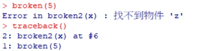

## browser

讓你在程式執行中的某個步驟停下來，互動式地查看目前變數、相關設定狀態等。  
一種用法是直接放在懷疑可能有錯的位置前後。出現 `Browse[1]>` 之後，輸入 c 表示繼續（直到下一個迴圈），輸入n 是執行下一行，Q代表退出。 （參考主要教材8.3節）

```r
 my_fun <- function(x) {
 browser()
 y <- x * z
 return(y)
 }
```

另一用法是 `options(error = browser)` 一旦有錯誤發生，就自動跳出 `Browse[1]>` 。但沒有以下介紹的 recover 那麼有彈性。

## debug 與 trace

有時函式不是我們自己寫的，直接插入 browser()、cat() 或 print() 不方便甚至不可行，此時就需要「觸發」的機制。

debug(“func”) 是每當func被呼叫，就會跳出 `Browse[1]>` 讓你檢查。 debugonce(“func”) 是當第一次func被呼叫會跳出 `Browse[1]>` ，之後就不會。 undebug(“func”) 則是取消這種一呼叫就觸發的行為。

trace(“func”) 是每當func被呼叫，就會回報func用了哪些輸入的值。 untrace(“func”) 則是取消這種一呼叫就觸發的行為。

可參考 debug 與 trace 說明文件中的範例。

## 用 Rstudio 的停止點設置

Rstudio 有某些除錯的介面，在反覆除錯時會方便一些。請見  
https://support.rstudio.com/hc/en-us/articles/200713843

## try, tryCatch 與其他例外處理

有時我們不確定程式到底能不能執行，或是一萬次周會有幾次莫名其妙出錯，這時可以用 try 避開迴圈中斷需手動介入的窘境。

有時程式未必是有錯，只是會出現一些例外狀況，用 trycatch 可以幫忙處理這些狀況。以下是常見例外狀況相關的處置方式。 * stop for fatal errors, message for diagnostic messages, warnings, and options with argument warn=.

# *pipe and debugging*

先前介紹過 `%>%` (pipe) 的用法，會讓程式較簡潔，但實際上R中不只這種pipe。  
大部都在rmonad 套件中，而且裡面已經包含一些錯誤處理。

我們得先了解一下 monad 的概念：  
http://www.ruanyifeng.com/blog/2015/07/monad.html

再來看rmonad才不會一頭霧水。 https://cran.r-project.org/web/packages/rmonad/vignettes/introduction.html